# Basic Hypothesis Testing

# Non-parameteric “t-tests”

## What do I do if my data are non-normally distributed?

- Have faith in the Central Limit Theorem. So long as you have a sample size of 30 or more you can assume that the sampling distribution of the sample mean follows the normal distribution (even if the original measurement does not come from a normal distribution)
- Test statistics for means & confidence intervals of means will be unaffected so long as you have a ``large enough’’ sample to work with
  - Most tests are robust to some violations of the normality assumption so long as the sample size is not too small and the skew isn’t very extreme
  - How small? If there is similar skewness, even when comparing two groups, having 30 in each group will work
  - If I have one group with severe skewness (one left-skewed the other right-skewed) then I need samples of a few hundred units each before the test can be trusted
- If all else fails (or you are a conservative analyst), try to transform the data and rerun all tests … We will try this tactic next
- If this doesn’t solve the problem (or you are not a fan of massaging your data) then switch to tests that do not require the Normality assumption … We will also see these tests in action in a bit.

### Transforming Data

If we are uncomfortable with ignoring violations of the normality assumption we have no choice but to transform the data. Several transformations are available for use, each with the goal of reducing the skew in the sample (i.e., rendering it more “normally” distributed).

1. Log Transformation
   $$X^{'} = ln\left( X \right)$$
   This is very commonly used in biological research to reduce skew. It usually works so long as the measure does not include $0$. If it does, then standard practice entails adding $1$ to each measurement and then taking the natural logarithm.

The log transformation is most useful when:

1. the measures represent ratios or products
2. The data are positively skewed (i.e., skewed right)
3. The group with the larger mean also has the larger standard deviation
4. The data span several orders of magnitude
- If substantially positively skewed and $X > 0$ then use $X^{'} = ln(X)$
- If substantially positively skewed and $X \geq 0$ then use $ln(X + c)$; where $c$ is a constant chosen such that the smallest score $= 1$
- If substantially negatively skewed then use $ln(K - X)$; where $K = X_{max} + 1$ so that the smallest score $=1$
2. Square-root Transformation
   $$X^{'} = \left( \sqrt{X} \right)$$
   Used often when there is moderate skew, and with count data
- If moderately positively skewed and $X > 0$ then use $\sqrt{X}$
- If moderately positively skewed and $X \geq 0$ then use $\sqrt{X + 0.5}$
- If moderately negatively skewed use $\sqrt{K - X}$; where $K = X_{max} + 1$ so that the smallest score $=1$
3. Arcsine Transformation If data are proportions the **arcsine**: $arcsin\left( \sqrt{p}\right)$ is suggested but I would not do this readily … Proportions are essentially coming from your Binomial or Poisson distributions and in these cases we would rarely run a $t-test$ or fit a linear regression
4. Other Transformations The square $(X^{'} = X^{2})$ is used f the data are skewed left, and if this fails, then the anti-log might work $(X^{'} = e^{X})$.

If data are skewed right, the reciprocal may also work $(X^{'} = \frac{1}{X})$.

For the square and the reciprocal you need to have all measurements be positive. If they are negative then you need to multiple each by $-1$ and then carry out the transformation.

If we use a transformation, the estimated statistics have to be back-transformed to the original metric.

- The Natural Logarithm: $X^{'} = ln[X]$ if $X > 0$
- The Natural Logarithm: $X^{'} = ln[X + 1]$ if $X \geq 0$
- The Square Root: $X^{'} = \sqrt{X + \frac{1}{2}}$
- The Arcsine: $p^{'} =arcsin[\sqrt{p}]$

The Corresponding Back-transformations

- The Natural Logarithm: $X = e^{X^{'}}$
- The Square Root: $X = X^{'2} - \frac{1}{2}$
- The Arcsine: $p = \left(sin[p^{'}]\right)^{2}$

# Nonparametric Alternatives to the $t-tests$

Non-parametric tests are used (a) when transformations do not work, or (b) the data represent ordinal categories (or are ranked data)

- Called non-parametric because unlike, say, the $t-test$ which requires some distributional assumption to be true (i.e., Normality) and involves parameters (i.e., the mean and the variance), these alternatives make no such assumptions or need no such parameters
- They are more likely to commit a Type II error so **if the assumptions of parametric tests are met use parametric tests**
- Here are a few non-parametric analogues to the $t-tests$:
  - Sign Test: Alternative to the One-Sample $t-test$ or to the Paired $t-test$
  - Wilcoxon Signed-Rank Test: Alternative to the Paired $t-test$
  - Mann-Whitney $U-test$: Alternative to the Two-Sample $t-test$ with equal variances
  - Kolmogorov-Smirnov test: Alternative to the Two-Sample $t-test$ with unequal variances

## The Sign Test

Assumption: Samples are drawn independently from a continuous distribution

- Tests whether the Median equals a hypothesized value ($H_0$ value)
- Scores above the $H_0$ value are marked $+$; scores below are marked $-$
- Scores $=$ to the Median are dropped
- If $H_0$ is correct then 50% of the scores should be $+$ and 50% should be $-$
- Essentially a Binomial test where $p_0=0.50$
- One-Sample Hypotheses: *$H_0$: The distribution is symmetric around $p=0.50$
  - $H_A$: The distribution is not symmetric around $p \neq 0.50$
- Paired Design Hypotheses:
  - $H_0$: The distribution of the two measurements is the same
  - $H_A$: The distribution of the two measurements is not the same
- Has little power because it is simplistic and works best with large samples

#### An Example of the Sign Test

The process by which a single species splits into two species is still not well understood. One proposal involves ``sexual conflict’’ – a genetic arms race between males and females that arises from their different reproductive roles. For example, in a number of insect species, male seminal fluid contains chemicals that reduce the tendency of the female to mate again with other males. However, these chemicals also reduce female survival, so females have developed mechanisms to counter these chemicals. Sexual conflict can cause rapid genetic divergence between isolated populations of the same species, leading to the formation of new species. Sexual conflict is more pronounced in species in which females mate more than once, leading to the prediction that they should form new species at a more rapid rate.

To investigate this, Arnqvist et al. (2000) identified 25 insect taxa (groups) in which females mate multiple times, and they paired each of these groups to a closely related insect group in which females only mate once. Which type of insects tend to have more species? Note: These are treated as paired data because the two sets of groups are closely related

```r
taxa = read.csv(url("http://whitlockschluter.zoology.ubc.ca/wp-content/data/chapter13/chap13e4SexualConflict.csv"))
head(taxa)
```

| taxonPair | nSpeciesMultipleMating | nSpeciesSingleMating | difference |
| --- | --- | --- | --- |
| A | 53 | 10 | 43 |
| B | 73 | 120 | -47 |
| C | 228 | 74 | 154 |
| D | 353 | 289 | 64 |
| E | 157 | 30 | 127 |
| F | 300 | 4 | 296 |

```r
names(taxa)
```

```
## [1] "taxonPair"              "nSpeciesMultipleMating"
## [3] "nSpeciesSingleMating"   "difference"
```

```r
summary(taxa)
```

|  | taxonPair | nSpeciesMultipleMating | nSpeciesSingleMating | difference |
| --- | --- | --- | --- | --- |
|  | A : 1 | Min. : 7 | Min. : 4.0 | Min. : -980.0 |
|  | B : 1 | 1st Qu.: 34 | 1st Qu.: 10.0 | 1st Qu.: -3.0 |
|  | C : 1 | Median : 77 | Median : 30.0 | Median : 16.0 |
|  | D : 1 | Mean : 1134 | Mean : 263.5 | Mean : 870.5 |
|  | E : 1 | 3rd Qu.: 228 | 3rd Qu.: 115.0 | 3rd Qu.: 79.0 |
|  | F : 1 | Max. :21000 | Max. :3500.0 | Max. :20940.0 |
|  | (Other):19 | NA | NA | NA |

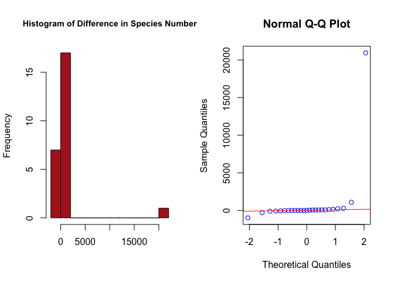

```r
par(mfrow = c(1, 2))
hist(taxa$difference, breaks = 9, col = "firebrick", main = "Histogram of Difference in Species Number",
    xlab = "", cex.main = 0.9)
qqnorm(taxa$difference, col = "blue")
qqline(taxa$difference, col = "red")
```

```r
par(mfrow = c(1, 1))

shapiro.test(taxa$difference)
```

```
##
##  Shapiro-Wilk normality test
##
## data:  taxa$difference
## W = 0.25473, p-value = 2.911e-10
```

The difference reflects negative values so what do we do? We can try the following:

```r
log.diff = log(taxa$difference + (2 - min(taxa$difference)))
summary(log.diff)

boxplot(log.diff, horizontal = TRUE)
shapiro.test(log.diff)
```

[output not shown]

That didn’t work. We could try some R packages designed to help transform the data but that would be pretty useless. Consequently, we might as well opt for the Sign Test.

$H_0$: Median difference in number of species is $= 0$  
$H_A$: Median difference in number of species is $\neq 0$

Let us use the BSDA library that has the test built-in. The commands below assume the data are from two groups, not the same group measured twice. This is in fact the case in our example so we are on the right track.

```r
library(BSDA)
SIGN.test(taxa$nSpeciesMultipleMating, taxa$nSpeciesSingleMating,
    md = 0, alternative = "two.sided", conf.level = 0.95)
```

```
##
##  Dependent-samples Sign-Test
##
## data:  taxa$nSpeciesMultipleMating and taxa$nSpeciesSingleMating
## S = 18, p-value = 0.04329
## alternative hypothesis: true median difference is not equal to 0
## 95 percent confidence interval:
##   1.00000 77.16674
## sample estimates:
## median of x-y
##            16
```

|  | Conf.Level | L.E.pt | U.E.pt |
| --- | --- | --- | --- |
| Lower Achieved CI | 0.8922 | 1 | 70.0000 |
| Interpolated CI | 0.9500 | 1 | 77.1667 |
| Upper Achieved CI | 0.9567 | 1 | 78.0000 |

Given the p-value we can reject $H_0$; the Median difference is not $=0$. The data suggest that groups of insects whose females mate multiple times have more species than groups whose females mate singly, consistent with the sexual-conflict hypothesis.

If we had the same units measured twice we would have run the command slightly differently.

```r
SIGN.test(taxa$difference, md = 0, alternative = "two.sided",
    conf.level = 0.95)
```

```
##
##  One-sample Sign-Test
##
## data:  taxa$difference
## s = 18, p-value = 0.04329
## alternative hypothesis: true median is not equal to 0
## 95 percent confidence interval:
##   1.00000 77.16674
## sample estimates:
## median of x
##          16
```

|  | Conf.Level | L.E.pt | U.E.pt |
| --- | --- | --- | --- |
| Lower Achieved CI | 0.8922 | 1 | 70.0000 |
| Interpolated CI | 0.9500 | 1 | 77.1667 |
| Upper Achieved CI | 0.9567 | 1 | 78.0000 |

Let us also see how to run the Sign test manually: First thing we will do is count how many cases are $+$, how many are $-$, and how many are equal to the hypothesized median of $0$

```r
taxa$sign = "equal to median"
taxa$sign[taxa$difference > 0] = "plus"
taxa$sign[taxa$difference < 0] = "minus"
taxa$sign = factor(taxa$sign, levels = c("minus", "equal to median",
    "plus"))
kable(taxa)
```

| taxonPair | nSpeciesMultipleMating | nSpeciesSingleMating | difference | sign |
| --- | --- | --- | --- | --- |
| A | 53 | 10 | 43 | plus |
| B | 73 | 120 | -47 | minus |
| C | 228 | 74 | 154 | plus |
| D | 353 | 289 | 64 | plus |
| E | 157 | 30 | 127 | plus |
| F | 300 | 4 | 296 | plus |
| G | 34 | 18 | 16 | plus |
| H | 3400 | 3500 | -100 | minus |
| I | 20 | 1000 | -980 | minus |
| J | 196 | 486 | -290 | minus |
| K | 1750 | 660 | 1090 | plus |
| L | 55 | 63 | -8 | minus |
| M | 37 | 115 | -78 | minus |
| N | 100 | 30 | 70 | plus |
| O | 21000 | 60 | 20940 | plus |
| P | 37 | 40 | -3 | minus |
| Q | 7 | 5 | 2 | plus |
| R | 15 | 7 | 8 | plus |
| S | 18 | 6 | 12 | plus |
| T | 240 | 13 | 227 | plus |
| U | 15 | 14 | 1 | plus |
| V | 77 | 16 | 61 | plus |
| W | 15 | 14 | 1 | plus |
| X | 85 | 6 | 79 | plus |
| Y | 86 | 8 | 78 | plus |

Here is a simple frequency of pluses and minuses

```r
table(taxa$sign)
```

| minus | equal to median | plus |
| --- | --- | --- |
| 7 | 0 | 18 |

So we have 7 minuses and 18 pluses. If the distribution were evenly spread we should have seen 50% of the cases below and 50% above the median. This is not what we see, but is this chance or something systematic? Let us apply the binomial test and see.

```r
binom.test(7, 25, p = 0.5)
```

```
##
##  Exact binomial test
##
## data:  7 and 25
## number of successes = 7, number of trials = 25, p-value = 0.04329
## alternative hypothesis: true probability of success is not equal to 0.5
## 95 percent confidence interval:
##  0.1207167 0.4938768
## sample estimates:
## probability of success
##                   0.28
```

## The Wilcoxon Signed-Rank Test

The Sign Test is weak in that it does not take into account the magnitudes of how much above/below the median an observation falls. The Wilcoxon Signed-Rank Test is a slight improvement because it ranks observations on the basis of how far below/above they fall from the hypothesized median.

- Assumes the distribution is symmetric around the Median … $=$ assumption of no skew so a very restrictive assumption
- Steps:
  - Calculate $X_i - \mu_{0}$ for all $i=1,2,\ldots,n$
  - Rank in ascending order the absolute differences $\left|X_i - \mu_{0} \right|$ for all $i=1,2,\ldots,n$
  - Assign + or - to each rank
  - Let the sum of + and - ranks be $W^{+}$ and $W^{-}$, respectively
  - Let $W = min\left(W^{+},W^{-}\right)$ and $W^{*}_{\alpha}$ be critical W
  - Reject $H_0$: The median difference between the two samples is $\mu_0 = 0$ if …
    - $H_A$: is $\mu \neq \mu_0$ and $W \leq W^{*}_{\alpha}$
    - $H_A$: is $\mu > \mu_0$ and $W^{-} \leq W^{*}_{\alpha}$
    - $H_A$: is $\mu < \mu_0$ and $W^{+} \leq W^{*}_{\alpha}$
- Normal approximation: $z_0 = \dfrac{W^{+} - n(n+1)/4}{\sqrt{n(n+1)(2n+1)/24}}$ … used when $n \geq 50$ and there are no ties

Let us run the test on the Sexual Conflict data:

```r
wilcox.test(taxa$nSpeciesMultipleMating, taxa$nSpeciesSingleMating,
    paired = TRUE)
```

```
##
##  Wilcoxon signed rank test with continuity correction
##
## data:  taxa$nSpeciesMultipleMating and taxa$nSpeciesSingleMating
## V = 230, p-value = 0.07139
## alternative hypothesis: true location shift is not equal to 0
```

Do not reject $H_0$; the distributions appear to be the same (i.e., there is no difference in the number of species between the polyandrous and the monandrous groups).

## The Mann-Whitney $U-test$

If we have a two-sample (i.e., unpaired) design, then the Mann-Whitney U-Test can be used assuming we couldn’t transform the data to run a $t-test$.

- The assumptions of the Mann-Whitney U test are:
- The variable of interest is continuous (not discrete). The measurement scale is at least ordinal
- The probability distributions of the two populations are identical, except for location (i.e., the ``center’’)
- The two samples are independent
- Both are simple random samples from their respective populations
- $H_0$: The samples come from populations with similar probability distributions
- Test Process and Statistic …
  - Combine both samples and rank, in ascending order, all values
  - If there are ties, rank accordingly
  - Sum the ranks of the smaller group $(R_1)$
  - $U_1$ = $n_1 n_2 + \dfrac{n_1(n_1 + 1)}{2} - R_{1}$; $U_2 = n_1 n_2 - U_{1}$
  - Choose the larger of $U_1$ or $U_2$ as the test statistic
  - Reject $H_0$ if $P-value \leq \alpha$

The sage cricket, *Cyphoderris strepitans*, has an unusual form of mating. During mating, the male offers his fleshy hind wings to the female to eat. The wounds are not fatal but a male with already nibbled wings is less likely to be chosen by females he meets later. Females get some nutrition from feeding on the wings, which raises the question, ``Are females more likely to mate if they are hungry?’’

Johnson et al. (1999) answered this question by randomly dividing 24 females into two groups: one group of 11 females were starved for at least two days and another group of 13 females was fed during the same period. Finally, each female was put separately into a cage with a single (new) male, and the waiting time to mating was recorded.

$H_0$: Time to mating is the same for female crickets that were starved as for those who were fed  
$H_A$: Time to mating is not the same for female crickets that were starved as for those who were fed

```r
cric = read.csv(url("http://whitlockschluter.zoology.ubc.ca/wp-content/data/chapter13/chap13e5SagebrushCrickets.csv"))
head(cric)
```

| feedingStatus | timeToMating |
| --- | --- |
| starved | 1.9 |
| starved | 2.1 |
| starved | 3.8 |
| starved | 9.0 |
| starved | 9.6 |
| starved | 13.0 |

```r
names(cric)
```

```
## [1] "feedingStatus" "timeToMating"
```

```r
wilcox.test(cric$timeToMating ~ cric$feedingStatus, paired = FALSE)
```

```
##
##  Wilcoxon rank sum test
##
## data:  cric$timeToMating by cric$feedingStatus
## W = 88, p-value = 0.3607
## alternative hypothesis: true location shift is not equal to 0
```

Do not reject $H_0$; time to mating does not appear to be different for starved versus fed female crickets

```r
gestures = read.csv(url("http://whitlockschluter.zoology.ubc.ca/wp-content/data/review2/rev2q13BlindGestures.csv"))
head(gestures)
```

| sightedness | numberOfGestures |
| --- | --- |
| Blind | 0 |
| Blind | 1 |
| Blind | 1 |
| Blind | 2 |
| Blind | 1 |
| Blind | 1 |

```r
names(gestures)
```

```
## [1] "sightedness"      "numberOfGestures"
```

```r
wilcox.test(gestures$numberOfGestures ~ gestures$sightedness,
    paired = FALSE)
```

```
##
##  Wilcoxon rank sum test with continuity correction
##
## data:  gestures$numberOfGestures by gestures$sightedness
## W = 62.5, p-value = 0.5755
## alternative hypothesis: true location shift is not equal to 0
```

```r
library(exactRankTests)
wilcox.exact(gestures$numberOfGestures ~ gestures$sightedness,
    paired = FALSE)
```

```
##
##  Exact Wilcoxon rank sum test
##
## data:  gestures$numberOfGestures by gestures$sightedness
## W = 62.5, p-value = 0.6361
## alternative hypothesis: true mu is not equal to 0
```

## Kolmogorov-Smirnov (K-S) Test

This (very weak) test is used to compare the distributions of two groups by comparing the empirical cumulative distribution functions (ecdfs) of the two groups and finding the greatest absolute distance between the two

- The $ecdf$ is $\hat{F}(X) =$ fraction of sample with values $\leq X_i$ , where $i=1,2,3, \cdots, n$
- The $K-S$ statistic is $D_{max} = | \hat{F}_1(X) - \hat{F}_2(X) |$
- Assumptions:
  - The measurement scale is at least ordinal.
  - The probability distributions are continuous
  - The two samples are mutually independent
  - Both samples are simple random samples from their respective populations
- $H_0:$ $F_1(X) = F_2(X)$ for all $X_i$; $H_A:$ $F_1(X) \neq F_2(X)$ for at least one $X_i$
- Reject $H_0$ if $P-value$ of calculated $D_{max} \leq \alpha$

#### An Example

Let us plot the distribution and run the formal tests to see if we can stick with the usual $t-test$

```r
eyes = read.csv(url("http://whitlockschluter.zoology.ubc.ca/wp-content/data/chapter12/chap12q18StalkieEyespan.csv"))
head(eyes)
```

| food | eyeSpan |
| --- | --- |
| Corn | 2.15 |
| Corn | 2.14 |
| Corn | 2.13 |
| Corn | 2.13 |
| Corn | 2.12 |
| Corn | 2.11 |

```r
names(eyes)
```

```
## [1] "food"    "eyeSpan"
```

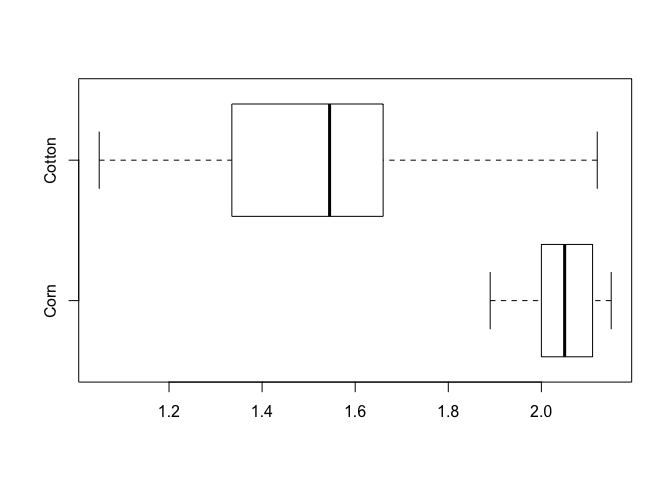

```r
boxplot(eyes$eyeSpan ~ eyes$food, horizontal = TRUE)
```

```r
var.test(eyes$eyeSpan ~ eyes$food)
```

```
##
##  F test to compare two variances
##
## data:  eyes$eyeSpan by eyes$food
## F = 0.068748, num df = 20, denom df = 23, p-value = 9.646e-08
## alternative hypothesis: true ratio of variances is not equal to 1
## 95 percent confidence interval:
##  0.0291719 0.1663771
## sample estimates:
## ratio of variances
##           0.068748
```

```r
library(car)
leveneTest(eyes$eyeSpan, eyes$food, center = "mean")
```

|  | Df | F value | Pr(>F) |
| --- | --- | --- | --- |
| group | 1 | 14.76323 | 0.0003965 |
|  | 43 | NA | NA |

```r
leveneTest(eyes$eyeSpan, eyes$food, center = "median")
```

|  | Df | F value | Pr(>F) |
| --- | --- | --- | --- |
| group | 1 | 14.7773 | 0.0003943 |
|  | 43 | NA | NA |

The box-plots and the formal tests (at least Levene’s test for homogeneity of variances) suggest we should reject the null of equal variances. We could try and normalize the data via the natural logarithm.

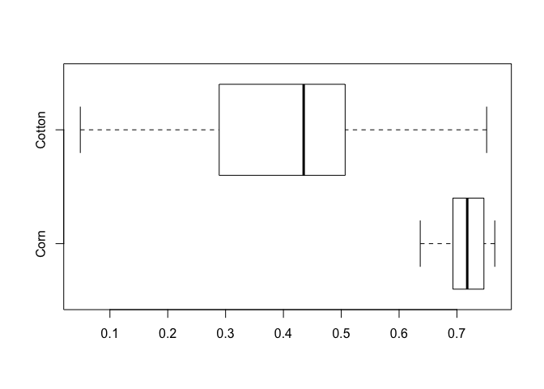

```r
eyes$log.span = log(eyes$eyeSpan)
boxplot(eyes$log.span ~ eyes$food, horizontal = TRUE)
```

```r
var.test(eyes$log.span ~ eyes$food)
```

```
##
##  F test to compare two variances
##
## data:  eyes$log.span by eyes$food
## F = 0.040201, num df = 20, denom df = 23, p-value = 7.154e-10
## alternative hypothesis: true ratio of variances is not equal to 1
## 95 percent confidence interval:
##  0.01705872 0.09729156
## sample estimates:
## ratio of variances
##         0.04020145
```

```r
leveneTest(eyes$log.span, group = eyes$food, center = "mean")
```

|  | Df | F value | Pr(>F) |
| --- | --- | --- | --- |
| group | 1 | 19.99886 | 5.58e-05 |
|  | 43 | NA | NA |

```r
leveneTest(eyes$log.span, group = eyes$food, center = "median")
```

|  | Df | F value | Pr(>F) |
| --- | --- | --- | --- |
| group | 1 | 18.63644 | 9.13e-05 |
|  | 43 | NA | NA |

Now we have a quandary, using both the mean and the median tells us we must reject $H_0$. A safe approach would be to assume we cannot normalize the data so the Kolmogorov-Smirnov test may be called for.

```r
ks.test(eyes$food, eyes$eyeSpan, alternative = "two.sided")
```

```
##
##  Two-sample Kolmogorov-Smirnov test
##
## data:  eyes$food and eyes$eyeSpan
## D = 0.46667, p-value = 0.0001109
## alternative hypothesis: two-sided
```

Uh oh! We have ties so this won’t work. Technically, a permutation test would be useful here but we won’t look at its mechanics until a later point this semester. For now though, we can run the test to close the loop.

```r
library(exactRankTests)
perm.test(eyes$eyeSpan ~ eyes$food, paired = FALSE, alternative = "two.sided",
    exact = TRUE)
```

```
##
##  2-sample Permutation Test (scores mapped into 1:(m+n) using
##  rounded scores)
##
## data:  eyes$eyeSpan by eyes$food
## T = 855, p-value = 9.363e-09
## alternative hypothesis: true mu is not equal to 0
```

Wel, we might as well try the `coin` library then.

```r
library(coin)
independence_test(eyes$eyeSpan ~ eyes$food, alternative = "two.sided")
```

```
##
##  Asymptotic General Independence Test
##
## data:  eyes$eyeSpan by eyes$food (Corn, Cotton)
## Z = 5.095, p-value = 3.487e-07
## alternative hypothesis: two.sided
```

The test tells us we can easily reject $H_0$; diet appears to have an effect on eye spans.

##### The Empirical Cumulative Distribution Function

There are several ways to plot this.

```r
library(Hmisc)
Ecdf(~eyeSpan | food, data = eyes)
```

[figure not shown]

The plot above was generated via the `Hmisc` library but you could also whip one up by hand. See below for an example.

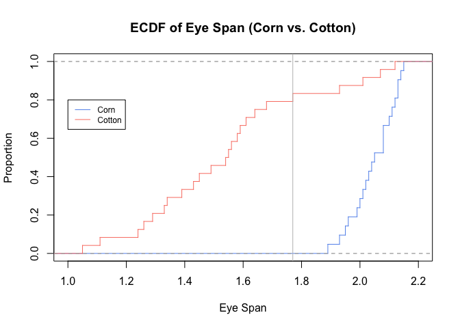

```r
fed = subset(eyes, food == "Corn")
starved = subset(eyes, food == "Cotton")

plot(ecdf(fed$eyeSpan), do.points = FALSE, verticals = TRUE,
    xlim = c(1, 2.2), pch = 46, col = "cornflowerblue", xlab = "Eye Span",
    ylab = "Proportion", main = "ECDF of Eye Span (Corn vs. Cotton)")
lines(ecdf(starved$eyeSpan), do.points = FALSE, verticals = TRUE,
    pch = 46, col = "salmon")
abline(v = 1.77, col = "gray")
legend(1, 0.8, legend = c("Corn", "Cotton"), col = c("cornflowerblue",
    "salmon"), lwd = 1, cex = 0.75)
```

## The Testing Sequence

- One-Sample or Paired Design
  - Test for Normality
  - If $N()$ holds then use the One-Sample $t-test$
  - If $N()$ does not hold then try a transformation, test for $N()$ again
  - If $N()$ still does not hold then use the Sign test (one sample) or the Wilcoxon Signed-Rank test (paired design)
- Two Sample design (equal variances)
  - Test for Normality and equal variances
  - If $N()$ holds and variances are equal then use the Two-Sample $t-test$ with $var.equal=TRUE$
  - If $N()$ does not hold then try a transformation, test for $N()$ again
  - If $N()$ still does not hold then use the Mann-Whitney $U-test$
- Two Sample design (unequal variances)
  - Test for Normality and equal variances
  - If $N()$ holds but variances are unequal then use the Two-Sample $t-test$ with $var.equal=FALSE$
  - If $N()$ does not hold then try a transformation, test for $N()$ again
  - If $N()$ still does not hold then use the Kolmogorov-Smirnov test